**CS4515** - 3D Computer Graphics and Animation

Elmar Eisemann, Ricardo Marroqium

# GLSL Shaders

# Exercise set 3: Shading with modern OpenGL

In these exercises you will implement a variety of shading and material models using modern OpenGL, as explained in the accompanying tutorial.

More specifically, in this assignment you will:

- Implement a variety of shading effects as Modern OpenGL fragment shaders
- Implement a variety of light-placement strategies

The code template for this assignment contains the neccesary boilerplate for loading a 3D scene and rendering it with modern OpenGL.

[figure not shown]

At startup we read the file `resources/default_scene.toml` to set the initial state of the scene, and then provide UI for changing the scene state manually, and rendering it with multiple shaders. Feel free to modify this file to change your default scene:

```
# default_scene.toml

[mesh]
path = "resources/dragon.obj"

[material]
kd = [0.5, 0.5, 0.5]
ks = [0.5, 0.5, 0.5]
shininess = 3.0
toonDiscretize = 4.0
toonSpecularThreshold = 0.49

[lights]
positions = [[0.4, 1.2, 0.2]]
colors = [[0.9, 0.9, 0.9]]

[camera]
lookAt = [0.0, 0.0, -1.0]
rotations = [0.0, 0.0, 0.0]
dist = 2.0
fovy = 50.0
```

# Reminder: Illumination models

In the previous introduction we assumed that we outpout the colors per vertex in the vertex shader and interpolate those values in the fragment shader. However, we will get higher quality results if we compute the illumination per pixel in the fragment shader.

For the following exercises you will be expected to write fragment shaders which compute the color of a pixel in a triangle. Please have a look at the provided vertex shader and debug fragment shader which are located in the shaders folder. This fragment shader takes the world space normal that is passed by the vertex shader and reinterprets it as a RGB value.

To place the light at the current camera position press $l$. To add a second light, use $L$. For this exercise, we will always assume to have white light sources.

## Lambertian Model

First, we will define a simple diffuse surface. The main part of the formula is $k_d \; \text{dot}(N,L)$, where $L$ is the direction of the point to the light and $N$ its normal. Use the $k_d$ value that is stored in `shadingData`.

For more information: http://en.wikipedia.org/wiki/Lambertian_reflectance

**Exercise: Implement a Lambertian Model in the main function of `shaders/lambert_frag.glsl`**.

Use uniforms to pass variables to your fragment shader. Modify the main rendering loop where it says `// === SET YOUR LAMBERT UNIFORMS HERE ===` to pass the CPU values to the uniforms that you’ve defined in your shader. You can set the uniform values using `glUniform`:

```cpp
glUniform1i(uniformIndex, intValue);
glUniform1f(uniformIndex, floatValue);
glUniform3fv(uniformIndex, 1, glm::value_ptr(glmVector));
```

## Phong Model

**Exercise: Implement the Phong model in `shaders/phong_frag.glsl` which introduces view-dependent effects (specularities).**

Its main formula looks like this : $k_s dot(R,V)^s$, where $R$ is the reflection vector (the reflected vector from the light at the plane defined by the surface’s normal) and $V$ is the vector from the surface point towards the camera position. You can make use of the build-in glsl function `reflect`. Be aware that it assumes that the light vector is pointing towards the surface. Use the $k_s$ value that is stored in `shadingData`. The camera position is stored in the `cameraPos` variable. Modify `main.cpp` to pass the required uniform variables (the comments will indicate where to put your code).

## Blinn-Phong Model

**Exercise: Implement the Blinn-Phong model which also takes view-dependent effects (specularities) into account in `shaders/blinn_phong_frag.glsl`**.

Its main formula looks like this: $\text{dot}(H,N)^s$, where $H$ is the unit vector exactly between the view direction $V$ and the direction towards the light. $s$ is the specular exponent (in the code called shininess) and influences the size of the highlight.

More can be found [here](https://en.wikipedia.org/wiki/Blinn-Phong_reflection_model).

**What impact does $s$ have?**

**If, for an even exponent, a light behind the model illuminates it, you might have to add a fix!**

## Diffuse Toon shading

Toon shading gives the impression of looking at a comic drawing. In our case, all you need to do is quantize the diffuse (Lambert) illumination. This means that there are `shadingData.toonDiscretize` uniform intervals between $0$ and $k_d$. A possible result would look like this:

[figure not shown]

We can also apply toon shading to specular highlights. Compute the Blinn-Phong specular highlights, if it has a value larger than or equal to `shadingData.toonSpecularThreshold` then make the pixel white, otherwise discard it or return black.

**Exercise: Implement the diffuse toon-shading shader in *shaders/toon_diffuse_frag.glsl* and the specular toon shader in *shaders/toon_specular_frag.glsl*.**

[figure not shown]

*Toon shading (left without, right with specularities)*

## X-Toon shading

The downside of toon shading is that it is hard to control the effect as an artist. For example, it is not possible to easily color shadows differently from lit areas. X-Toon shading is an extended version of toon shading that tackles this problem by using a texture to lookup the lighting instead of doing math inside the shader itself:

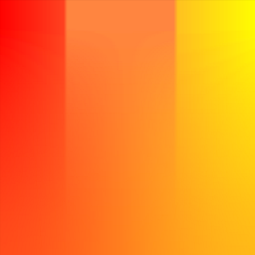

Instead of doing math on the brightness value in the shader, it is used to do a color lookup in this texture. You’ll already recognize three distinct shades in the textures, similar to our previous toon shader.

As you may have already noticed, textures in OpenGL are created similarly to Vertex Buffer Objects. You create a Texture Object using `glCreateTextures`, allocate it using `glTextureStorage2D` and then upload data to it with `glTextureSubImage2D`. In OpenGL you cannot just sample an arbitrary texture in your shader, you will have to bind it to a certain slot like `GL_TEXTURE0` or `GL_TEXTURE7`. This is done by first making a slot active with `glActiveTexture` and then binding a texture with `glBindTexture`. You can then access this texture in a shader by using a special `uniform` variable:

```
uniform sampler2D texToon;
```

The `sampler2D` type specifies a sampler object through which you can access a texture. This sampler is assigned a specific texture slot index with the `glUniform1i` call. The behavior of texture sampling is set with the `glTextureParameteri` call. For example, you can configure:

- What should happen when accessing the texture beyond the $[0, 1]$ range?
- How should a color between pixels be calculated?
- Should the texture have a border - and if so - what color?

Sampling a texture beyond the $[0, 1]$ range is useful if you want to repeat a texture, for example, to fill a landscape with grass. Interpolating values between pixels will make a texture look smoother, although this may not be the intended effect if you want to go for an art style like Minecraft’s, for example.

The program you were given already loads the sample X-Toon map you saw before into a texture `texToon`. Note that this is a 2D image, but we will only use the first row for now. You can access a texture in the shader using the `texture` function like so:

```cpp
outColor = texture(texToon, vec2(0.0, 0.0));
```

The `texture` function takes the sampler variable and a texture coordinate as parameters. Texture coordinates are almost always in the $[0, 1]$ range instead of pixels coordinates like $[0, 512)$. The code above will sample the red color in the left corner of the texture, whereas the following code will sample the yellow right corner:

```cpp
outColor = texture(texToon, vec2(1.0, 0.0));
```

Now try using the brightness of the original Lambert + Blinn-Phong shading without toon effects to sample the texture. You should only vary the horizontal coordinate and keep the vertical coordinate `0.0`. That should result in something like this:

[figure not shown]

*Basic X-Toon Shading*

X-Toon shading uses the vertical axis in the texture to add details based on the distance between the viewer and the model. First try using the world-space distance between the viewer and the fragment to vary the brightness like below. You may need to offset the distance and scale it to make it look this way, otherwise most of the distance values are outside the $[0, 1]$ color range.

Now use this distance for the vertical coordinate in the texture lookup and you will get different styles for closer fragment and farther fragments like in the figure above.

[figure not shown]

[figure not shown]

*Left: distance from the camera. Right: full X-Toon shading.*

# And there was light!

Now, we will focus on the control of the illumination. For an artist, it can be very difficult to control the light positions (just look at the credits of any modern movie, you have hundreds of people working on the light placements!). Our goal is to simplify this work and provide the artist with a tool to efficiently place lights in an indirect manner.

We will use the function `userInteraction` in the following. This function receives, where the user has “clicked” (as the mouse button is used for the navigation, pressing `space` will launch this function instead of a click). This interaction will trigger the function `userInteraction`. We will use these functions to define a new light position, based on different criteria. To switch the interaction mode (hence, the userInteraction function that is called), use the `M` key or the UI dropdown. Please also read the indications in the source code.

## Placing the light with the mouse

**Exercise: Implement the function `userInteractionSphere`**

The function `userInteractionSphere` should place the light on a sphere of radius 1.5, centered at (0,0,0). Pay attention to choosing the intersection point closest to the observer - which can even be behind the observer!

## Placing the light according to shading

**Exercise: Implement the function `userInteractionShadow`**

This time, the new light position should be chosen such that the light produces a exactly a lambertian shading of zero at the clicked location. (Use the mode Toon shading to verify your solution). There are several possibilities to achieve this goal! The implicit condition is that $dot(L, N)$ should be zero, which leaves some degrees of freedom. **Come up with a solution that you find appropriate and test if the light behaves “intuitively”.**

## Placing the light based on specularities

**Exercise: Implement the function `userInteractionSpecular`**

This function should place a light at a position such that there is a specularity centered at the clicked location. Placing a specularity is not easy because its position depends on the view AND the light.

## Multiple light sources

Use the combination `shift+L` to add lights in the scene. To restart from scratch with all your light sources, press `shift+N` (or Reset “Lights in UI”).

## Controlling the parameters

We would like to add colored sources, which will be possible by by modifying `lights[xxx].color`. It will contain the RGB triplet for each light source, which represents its color.

**Exercise: Implement keyboard controls for light color**

Complete the function *keyboard* and add the keys for `R, G, B, r, g, b`. Capital letters should increment, small letters reduce the corresponding RGB value of the color by a small constant, e.g., 0.1. The affected light should be the current one, which is stored in a global variable `selectedLight` and can be changed by the `+` and `-` keys or clicking the UI. The selected light can be determined on the screen by its border color.

Dont forget to change your fragment shaders to take light color into account